# PRESS 2016 - COUNTRY FACTSHEETS

```
                                       Morocco
```

Download this factsheet as PDF

The PRESS exercise is conducted annually to report on trends across time in support to statistics. The 2016 PRESS uses newly available data from an annual donor survey and the Creditor Reporting System (CRS) round of 2014 to update figures on aid to statistics for 2006 to 2013 (previously reported in the 2015 PRESS) and report new figures for commitments in 2014. The new 2014 figures are expected to be adjusted upwards to the levels of previous years 2011-2013 as additional projects for 2014 will be reported later this year.All findings should therefore be interpreted with this caveat in mind.

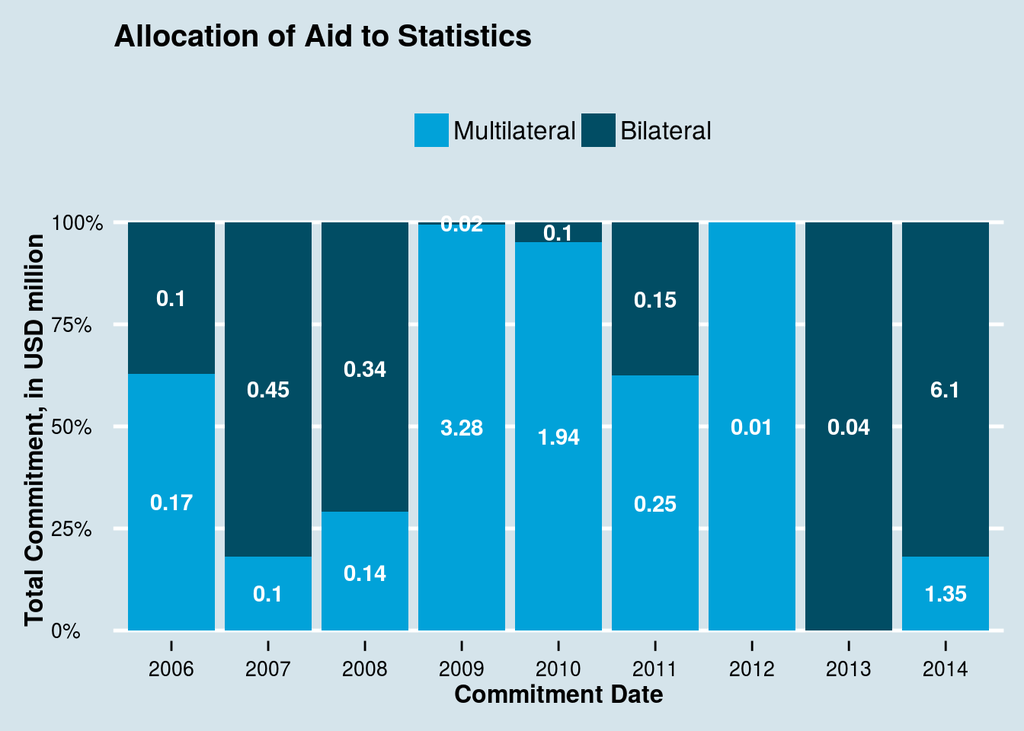

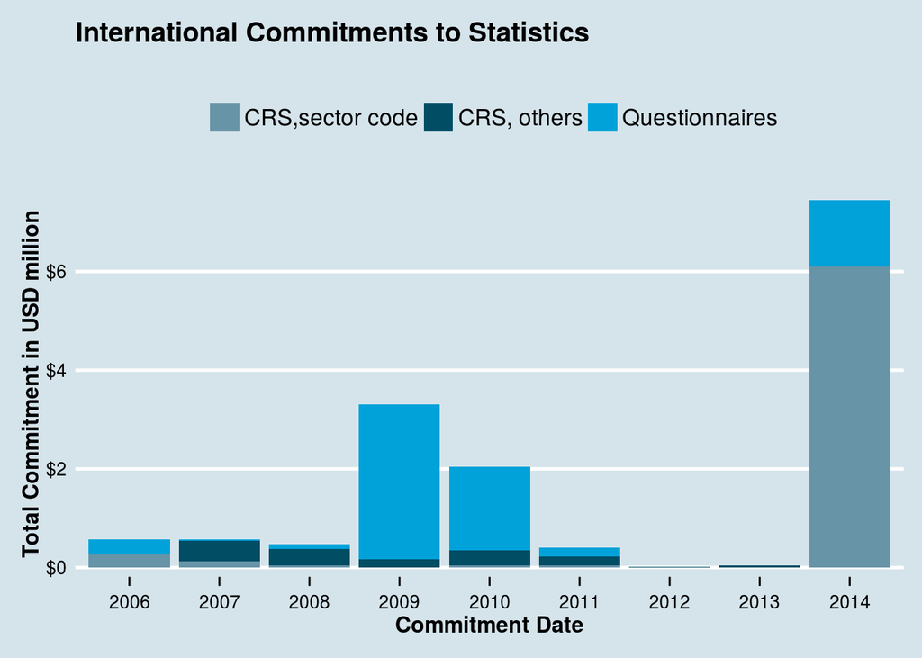

> Fig1. Allocation of Aid to Statistics

Multilateral[^1], country-specific assistance remains globally the most popular means through which donors channel support to countries. Considering all recipients reported in the PRESS, support from multilateral bodies accounted for less than 50% of total aid to statistics in 2009-2010 but increased to approximately 70% in 2011 and 2012, respectively. However, the shares of country-specific[^2] aid diminished slightly between 2012 and 2014.

> Fig2. International Commitments to Statistics

Support to statistics remains globally low. Considering all recipients reported in the PRESS, total 2014 commitments to statistical development of about USD 470 million show a 20% decrease from previous years 2011 and 2013. The decrease in commitments in 2014 led to a drop in the share of ODA dedicated to statistics from 0.31% in 2012 and 2013 to 0.25% in 2014. This should, however, not be interpreted as a general trend because commitments often span multiple years and fluctuations in annual figures are therefore common

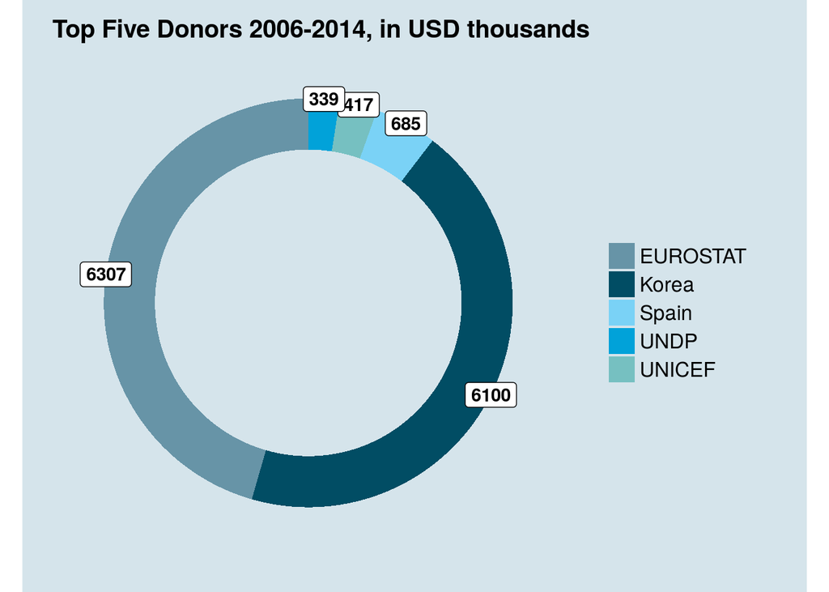

> Fig3. Top 5 Donors

A large share of global support to statistics continues to come from a very small number of providers. The top five providers of development co-operation in statistics for all countries reported in the PRESS (European Commission/EUROSTAT; The World Bank; IMF; FAO; Canada) provided 72% of total commitments in 2014. While Canada is strongly engaged in country-specific aid to statistics, the United Kingdom and Norway are among the top donors for unallocated commitments. Country-Specific commitments accounted for approximately 74% (USD 350 million) in 2014.

This table displays all projects whose Financing Amount is at least 10 000 USD.

| Provider | Projects | Amount | Type | Date |
| --- | --- | --- | --- | --- |
| **EFTA** | Mirror and reconciliation exercises for External Trade Statistics between Switzerland and Morocco | 25 | Grant | 2007 |
| **EUROSTAT** | Assistance technique à la Direction de la lutte contre l’analphabétisme (DLCA) dans l’amélioration des capacités des services décentralisés et des organisations partenaires en matière de planification… | 169 | Grant | 2011 |
| **EUROSTAT** | Assistance technique et développement d’études dans le cadre du Programme ‘’appui à la mise en oeuvre de la stratégie d’alphabétisation’’ | 1006 | Grant | 2009 |
| **EUROSTAT** | Contrat de Jumelage MA09/ENP-AP/FI16 - Appui à l’Office des changes dans le domaine de l’établissement des statistiques des échanges extérieurs | 1669 | Grant | 2010 |
| **EUROSTAT** | Programme d’appui à la consolidation de la Couverture Medicale de Base (CMB) au Maroc - Contrat d’assistance technique long terme CMB II | 2136 | Grant | 2009 |
| **EUROSTAT** | Programme d’appui à la politique forestière du Maroc - Assistance technique au programme d’appui de l’Union européenne à la politique forestière du Maroc | 1327 | Loan/credit | 2014 |
| **IMF** | Technical Assistance | 105 |  | 2008 |
| **IMF** | Statistics Department: Technical Assistance | 23 |  | 2010 |
| **IMF** | Statistics Department: Technical Assistance | 16 |  | 2011 |
| **IMF** | Statistics Department: Technical Assistance | 20 |  | 2014 |
| **IsDB** | Statistical Capacity Building of Central Bank of Morocco to analyse and formulate monetary policy and to its assess its macro-economic and financial impact (macro-economic modeling) | 298 | Grant | 2006 |
| **Japan** | TC AGGREGATED ACTIVITIES | 100 | Grant | 2006 |
| **Japan** | TC AGGREGATED ACTIVITIES | 39 | Grant | 2007 |
| **Korea** | PROJECT FOR THE STRENGTHENING OF THE STATISTICAL AND BUSINESS INTELLIGEN | 6100 | Grant | 2014 |
| **Norway** | MAROC - HOUSEHOLD INTERNATIONAL MIGRATION SURVEY | 44 | Grant | 2013 |
| **Spain** | ECONOMIC AND DEVELOPMENT POLICY/PLANNING | 411 | Grant | 2007 |
| **Spain** | TRAINING ON ELECTRONIC ENGINEERING AND APPROXIMATION METHODS OF EMPIRICAL DATA AND DEVELOPMENT OF RESEARCH INFRASTRUCTURES AT POLYDISCIPLINARY FACULTY | 19 | Grant | 2009 |
| **Spain** | POPULATION POLICY AND ADMIN. MGMT | 102 | Grant | 2010 |
| **Spain** | INVISIBLE CHILDREN: FOR THE RIGHT OF IDENTITY OF BOYS AND GIRLS NOT REGISTERED IN THE CIVIL PUBLIC REGISTRY OF 6 MARGINALIZED AREAS OF NORTHERN MOROC | 153 | Grant | 2011 |
| **UNDP** | BDD CRÉÉE NEW SERV. LIVRÉ | 64 | Grant | 2009 |
| **UNDP** | PÔLE DE GESTION MIS EN PLACE | 77 | Grant | 2009 |
| **UNDP** | POLE DE GESTION MIS EN PLACE | 27 | Grant | 2010 |
| **UNDP** | BDD CREEE NEW SERV. LIVRE | 169 | Grant | 2010 |
| **UNICEF** | MICS SURVEYS | 100 | Grant | 2006 |
| **UNICEF** | CP RESEARCH AND ANALYSIS | 17 | Grant | 2006 |
| **UNICEF** | DEVINFO DBASE DEVELOPMENT AND MAINTENANCE | 11 | Grant | 2006 |
| **UNICEF** | LIBRARY AND DOCUMENTATION CENTRES | 14 | Grant | 2006 |
| **UNICEF** | MONITORING AND REPORTING SYSTEMS ON CHILDREN/WOMEN | 21 | Grant | 2006 |
| **UNICEF** | MONITORING AND REPORTING SYSTEMS ON CHILDREN/WOMEN | 16 | Grant | 2007 |
| **UNICEF** | KNOWLEDGE MANAGEMENT NETWORKS (UNICEF) | 22 | Grant | 2007 |
| **UNICEF** | SITAN | 19 | Grant | 2007 |
| **UNICEF** | SITAN | 10 | Grant | 2008 |
| **UNICEF** | SUPPORT TO DHS AND OTHER HOUSEHOLD SURVEYS | 38 | Grant | 2010 |
| **UNICEF** | CHILD PROTECTION AND VIOLATIONS DATA COLLECTION, ANALYSIS, REPORTS AND USE | 24 | Grant | 2011 |
| **UNICEF** | SUPPORT TO MICS, DHS AND OTHER DATA COLLECTION SYSTEMS AND THEIR ANALYSES | 43 | Grant | 2011 |
| **UNICEF** | SITUATION ASSESSMENT AND ANALYSIS (SITAN) AND MDG MONITORING | 12 | Grant | 2012 |
| **USA** | DATA MANAGEMENT, INVESTMENT PROMOTION IN UPSTREAM PMD: (ONHYM) - TECHNICAL ASSISTANCE | 332 | Grant | 2008 |

**Source: PRESS 2016. The report was prepared by the Secretariat of the Partnership in Statistics for Development in the 21st Century (PARIS21)**

[^1]: Multilateral support in this context refers to support coming from multilateral institutions.
[^2]: Country-specific assistance refers to projects for which there is a single country recipient.